# Machine Learning Engineer Nanodegree

## Project: Titanic Survival Exploration

```python
# Required packages

import numpy as np
import pandas as pd
import matplotlib.pyplot as plt
%matplotlib inline
import seaborn as sns
```

```python
# Import supplementary visualizations code visuals.py
import visuals as vs
```

```python
# Load the dataset
in_file = "titanic_data.csv"
full_data = pd.read_csv(in_file)
```

```python
full_data.head()
```

|  | PassengerId | Survived | Pclass | Name | Sex | Age | SibSp | Parch | Ticket | Fare | Cabin | Embarked |
| --- | --- | --- | --- | --- | --- | --- | --- | --- | --- | --- | --- | --- |
| 0 | 1 | 0 | 3 | Braund, Mr. Owen Harris | male | 22.0 | 1 | 0 | A/5 21171 | 7.2500 | NaN | S |
| 1 | 2 | 1 | 1 | Cumings, Mrs. John Bradley (Florence Briggs Th... | female | 38.0 | 1 | 0 | PC 17599 | 71.2833 | C85 | C |
| 2 | 3 | 1 | 3 | Heikkinen, Miss. Laina | female | 26.0 | 0 | 0 | STON/O2. 3101282 | 7.9250 | NaN | S |
| 3 | 4 | 1 | 1 | Futrelle, Mrs. Jacques Heath (Lily May Peel) | female | 35.0 | 1 | 0 | 113803 | 53.1000 | C123 | S |
| 4 | 5 | 0 | 3 | Allen, Mr. William Henry | male | 35.0 | 0 | 0 | 373450 | 8.0500 | NaN | S |

### Variables definitions

From a sample of the RMS Titanic data, we can see the various features present for each passenger on the ship:

- **Survived**: Outcome of survival (0 = No; 1 = Yes)
- **Pclass**: Socio-economic class (1 = Upper class; 2 = Middle class; 3 = Lower class)
- **Name**: Name of passenger
- **Sex**: Sex of the passenger
- **Age**: Age of the passenger (Some entries contain `NaN`)
- **SibSp**: Number of siblings and spouses of the passenger aboard
- **Parch**: Number of parents and children of the passenger aboard
- **Ticket**: Ticket number of the passenger
- **Fare**: Fare paid by the passenger
- **Cabin** Cabin number of the passenger (Some entries contain `NaN`)
- **Embarked**: Port of embarkation of the passenger (C = Cherbourg; Q = Queenstown; S = Southampton)

```python
# Store the 'Survived' feature in a new variable and remove it from the dataset
outcomes = full_data['Survived']
data = full_data.copy()
data.drop('Survived', axis=1,inplace = True)
```

```python
data.head()
```

|  | PassengerId | Pclass | Name | Sex | Age | SibSp | Parch | Ticket | Fare | Cabin | Embarked |
| --- | --- | --- | --- | --- | --- | --- | --- | --- | --- | --- | --- |
| 0 | 1 | 3 | Braund, Mr. Owen Harris | male | 22.0 | 1 | 0 | A/5 21171 | 7.2500 | NaN | S |
| 1 | 2 | 1 | Cumings, Mrs. John Bradley (Florence Briggs Th... | female | 38.0 | 1 | 0 | PC 17599 | 71.2833 | C85 | C |
| 2 | 3 | 3 | Heikkinen, Miss. Laina | female | 26.0 | 0 | 0 | STON/O2. 3101282 | 7.9250 | NaN | S |
| 3 | 4 | 1 | Futrelle, Mrs. Jacques Heath (Lily May Peel) | female | 35.0 | 1 | 0 | 113803 | 53.1000 | C123 | S |
| 4 | 5 | 3 | Allen, Mr. William Henry | male | 35.0 | 0 | 0 | 373450 | 8.0500 | NaN | S |

```python
def accuracy_score(truth, pred):
    """ Returns accuracy score for input truth and predictions. """

    # Ensure that the number of predictions matches number of outcomes
    if len(truth) == len(pred):
        if sum(pred) == sum(truth): # Prediction matches reality
            result = 1
        elif sum(pred) < sum(truth): # prediction understimated survivors
            result = sum(pred) / sum(truth)
        else:                         # prediction overstimated survivors
            result = sum(truth) / sum(pred)
        # Calculate and return the accuracy as a percent
        return "Predictions have an accuracy of {:.2f}%.".format(result*100)

    else:
        return "Number of predictions does not match number of outcomes!"
```

```python
# Test the 'accuracy_score' function
predictions = pd.Series(np.ones(3, dtype = int))
print (accuracy_score(outcomes[:3], predictions))
```

```
Predictions have an accuracy of 66.67%.
```

# Making Predictions: Initial naive prediction, they all died

```python
def predictions_0(data):
    """ Model with no features. Always predicts a passenger did not survive. """

    predictions = []
    for _, passenger in data.iterrows():

        # Predict the survival of 'passenger'
        predictions.append(0)

    # Return our predictions
    return pd.Series(predictions)

# Make the predictions
predictions = predictions_0(data)
```

## Simpler way to create a pd.Series with 0s

```python
prediction1 = pd.Series(np.zeros(len(data['PassengerId'])),dtype = 'int64')
prediction1.shape
```

```
(891,)
```

```python
pd.Series.equals(prediction1,predictions)
```

```
True
```

## Question 1

*Using the RMS Titanic data, how accurate would a prediction be that none of the passengers survived?*

```python
accuracy_score(outcomes, prediction1)
```

```
'Predictions have an accuracy of 0.00%.'
```

**Answer**:

```python
print("Total # of passengers on the boat {:.0f}.".format(len(outcomes)))
print("Total # of passengers that survived {:.0f}.".format(len(outcomes[outcomes !=0])))
print("Survival rate {:.02f}%.".format((len(outcomes[outcomes !=0])/len(outcomes))*100))
print('prediction_0 has predicted 0% survivors, which implies that prediction_0 accuracy is 0' )
```

```
Total # of passengers on the boat 891.
Total # of passengers that survived 342.
Survival rate 38.38%.
prediction_0 has predicted 0% survivors, which implies that prediction_0 accuracy is 0
```

## Let us use vs.survival_stats to analyze the data

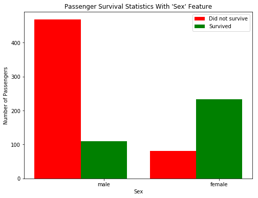

```python
vs.survival_stats(data, outcomes, 'Sex')
```

> **Key Conclusions:**
> 1. Large majority of males did not survive the ship sinking
> 2. Majority of females *did* survive the ship sinking

Upgrading prediction model: If a passenger was female, then we will predict that they survived. Otherwise, we will predict the passenger did not survive.

```python
sexos = set(data.Sex)
print(sexos)
```

```
{'male', 'female'}
```

```python
def predictions_1(data):
    """ Model with one feature:
            - Predict a passenger survived if they are female. """

    predictions2 = []
    for passenger in data['Sex']:
        if passenger == 'female':
            predictions2.append(1)
        else:
            predictions2.append(0)
    return pd.Series(predictions2)

# Make the predictions
predictions2 = predictions_1(data)
```

## Question 2

*How accurate would a prediction be that all female passengers survived and the remaining passengers did not survive?*

```python
print (accuracy_score(outcomes, predictions2))
```

```
Predictions have an accuracy of 91.81%.
```

**Answer**:

```python
print("Total # of passengers on the boat {:.0f}.".format(len(outcomes)))
print("Total # of passengers that survived {:.0f}.".format(len(outcomes[outcomes !=0])))
print("Survival rate {:.02f}%.".format((len(outcomes[outcomes !=0])/len(outcomes))*100))
print("Total # of females on the boat {:.0f}.".format(len(predictions2[predictions2 !=0])))
print('prediction_1 has predicted 314 of the 342 survivors, which implies that prediction_1 accuracy is {:.02f}%.'\
      .format((len(predictions2[predictions2 !=0])/len(outcomes[outcomes !=0]))*100))
```

```
Total # of passengers on the boat 891.
Total # of passengers that survived 342.
Survival rate 38.38%.
Total # of females on the boat 314.
prediction_1 has predicted 314 of the 342 survivors, which implies that prediction_1 accuracy is 91.81%.
```

Let's consider using an additional feature to see if we can further improve our predictions. For example, consider all of the male passengers aboard the RMS Titanic: Can we find a subset of those passengers that had a higher rate of survival? Let's start by looking at the **Age** of each male, by again using the `survival_stats` function. This time, we'll use a fourth parameter to filter out the data so that only passengers with the **Sex** 'male' will be included.  
Run the code cell below to plot the survival outcomes of male passengers based on their age.

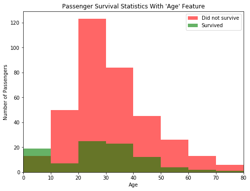

```python
vs.survival_stats(data, outcomes, 'Age', ["Sex == 'male'"])
```

The majority of males younger than 10 survived the ship sinking, whereas most males age 10 or older *did not survive* the ship sinking. Let's continue to build on our previous prediction: If a passenger was female, then we will predict they survive. If a passenger was male and younger than 10, then we will also predict they survive. Otherwise, we will predict they do not survive.

```python
data.head()
```

|  | PassengerId | Pclass | Name | Sex | Age | SibSp | Parch | Ticket | Fare | Cabin | Embarked |
| --- | --- | --- | --- | --- | --- | --- | --- | --- | --- | --- | --- |
| 0 | 1 | 3 | Braund, Mr. Owen Harris | male | 22.0 | 1 | 0 | A/5 21171 | 7.2500 | NaN | S |
| 1 | 2 | 1 | Cumings, Mrs. John Bradley (Florence Briggs Th... | female | 38.0 | 1 | 0 | PC 17599 | 71.2833 | C85 | C |
| 2 | 3 | 3 | Heikkinen, Miss. Laina | female | 26.0 | 0 | 0 | STON/O2. 3101282 | 7.9250 | NaN | S |
| 3 | 4 | 1 | Futrelle, Mrs. Jacques Heath (Lily May Peel) | female | 35.0 | 1 | 0 | 113803 | 53.1000 | C123 | S |
| 4 | 5 | 3 | Allen, Mr. William Henry | male | 35.0 | 0 | 0 | 373450 | 8.0500 | NaN | S |

```python
def predictions_2(data):
    """ Model with two features:
            - Predict a passenger survived if they are female.
            - Predict a passenger survived if they are male and younger than 10. """

    predictions3 = []
    for age, sex in zip(data['Age'],data['Sex']):
        if sex == 'female':
            predictions3.append(1)
        elif (sex == 'male') & (age < 11):
            predictions3.append(1)
        else:
            predictions3.append(0)

    return pd.Series(predictions3)

# Make the predictions
predictions3 = predictions_2(data)
```

## Question 3

*How accurate would a prediction be that all female passengers and all male passengers younger than 10 survived?*

```python
print (accuracy_score(outcomes, predictions3))
```

```
Predictions have an accuracy of 98.56%.
```

**Answer**:

```python
print("Total # of passengers on the boat {:.0f}.".format(len(outcomes)))
print("Total # of passengers that survived {:.0f}.".format(len(outcomes[outcomes !=0])))
print("Survival rate {:.02f}%.".format((len(outcomes[outcomes !=0])/len(outcomes))*100))
print("Total # of females and boys less than 11 years old on the boat {:.0f}.".format(len(predictions3[predictions3 !=0])))
print('prediction_2 has predicted 347 of the 342 survivors, which implies that prediction_2 accuracy is {:.02f}%, \nsince over estimated the number of survivors'\
      .format((len(outcomes[outcomes !=0])/len(predictions3[predictions3 !=0]))*100))
```

```
Total # of passengers on the boat 891.
Total # of passengers that survived 342.
Survival rate 38.38%.
Total # of females and boys less than 11 years old on the boat 347.
prediction_2 has predicted 347 of the 342 survivors, which implies that prediction_2 accuracy is 98.56%,
since over estimated the number of survivors
```

## Task:

Find a series of features and conditions to split the data on to obtain an outcome prediction accuracy of at least 80%. This may require multiple features and multiple levels of conditional statements to succeed.

### Step 1: let us look at the data

```python
data.info()
```

```
<class 'pandas.core.frame.DataFrame'>
RangeIndex: 891 entries, 0 to 890
Data columns (total 11 columns):
PassengerId    891 non-null int64
Pclass         891 non-null int64
Name           891 non-null object
Sex            891 non-null object
Age            714 non-null float64
SibSp          891 non-null int64
Parch          891 non-null int64
Ticket         891 non-null object
Fare           891 non-null float64
Cabin          204 non-null object
Embarked       889 non-null object
dtypes: float64(2), int64(4), object(5)
memory usage: 76.6+ KB
```

## Step 2:

Let us make a copy and get rid of the fields which do not carry predicting value:

1. Name
2. Ticket
3. Fare
4. Embarked
5. Cabin : The main reason not to use cabin is due to the significant lack of data (204 out of 891 data points)

```python
quantdata = full_data.copy()
```

```python
quantdata.drop(['Name','Ticket','Fare','Embarked','Cabin'], axis = 1,inplace =True)
```

## Since we are Machine Learning sorcerers better to work with numbers !!

```python
quantdata['Sex'] = quantdata['Sex'].map({'male':0,'female':1})
```

```python
quantdata.info()
```

```
<class 'pandas.core.frame.DataFrame'>
RangeIndex: 891 entries, 0 to 890
Data columns (total 7 columns):
PassengerId    891 non-null int64
Survived       891 non-null int64
Pclass         891 non-null int64
Sex            891 non-null int64
Age            714 non-null float64
SibSp          891 non-null int64
Parch          891 non-null int64
dtypes: float64(1), int64(6)
memory usage: 48.8 KB
```

```python
print(len(quantdata[(quantdata['Age'].isin([0,np.NaN])) & (quantdata['Sex'] == 0)]))
print(len(quantdata[quantdata['Sex'] == 0]))
print('We dont know the age of 20% of males which affects the use of younger than 11 rule')
```

```
124
577
We dont know the age of 20% of males which affects the use of younger than 11 rule
```

### Since we don't know the age of 20% of the males in the boat and age is one of our prediction parameters it would be useful to see if we can infer the age of males. Let us see if the ticket price can help to identify prices based on Age (sometimes you get different prices for young kids or elders)

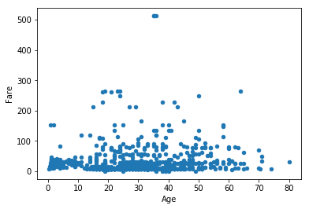

```python
full_data.plot(kind='scatter', x = 'Age', y ='Fare',figsize=(6,4));
```

### There is no linear association between age and fare, so clearly not much to do on that front.

### Let us take a more comprehensive approach

**Let us 1st fix the NaN issue**

```python
quantdata.Age.fillna(value = 0, inplace = True)
```

```python
quantdata.set_index('PassengerId', inplace=True)
```

```python
quantdata.info()
```

```
<class 'pandas.core.frame.DataFrame'>
Int64Index: 891 entries, 1 to 891
Data columns (total 6 columns):
Survived    891 non-null int64
Pclass      891 non-null int64
Sex         891 non-null int64
Age         891 non-null float64
SibSp       891 non-null int64
Parch       891 non-null int64
dtypes: float64(1), int64(5)
memory usage: 48.7 KB
```

## Let us look for Linear associations

```python
from pandas.plotting import scatter_matrix
```

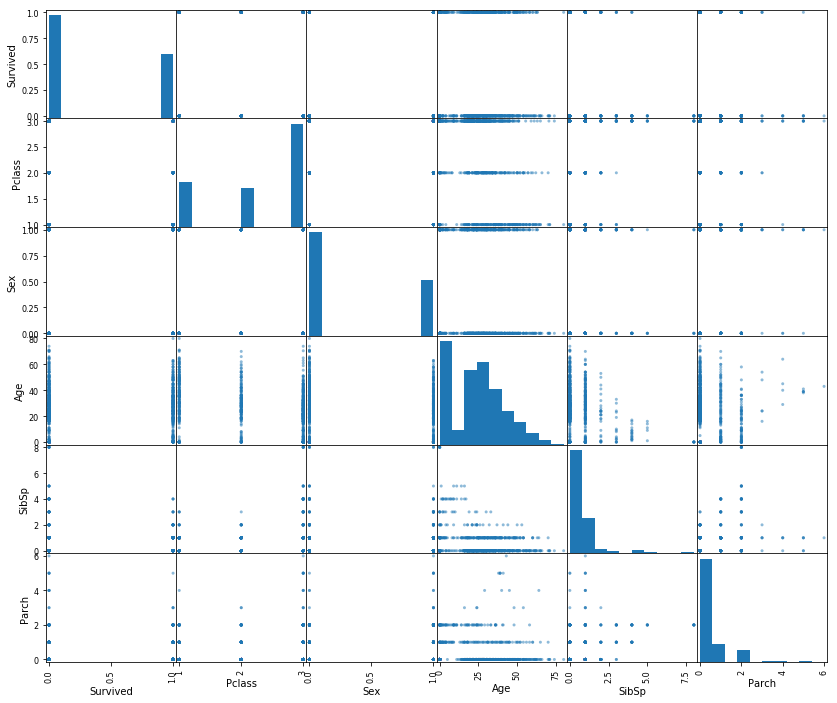

```python
scatter_matrix(quantdata, figsize=(14,12));
```

### Nothing of interest, I have to say given the fact that there is a lot of categorical data it is not so suprising....

## Let us look for a different angle

**Let us look at the data using a histogram comparing the full set versus the set of survivors only**

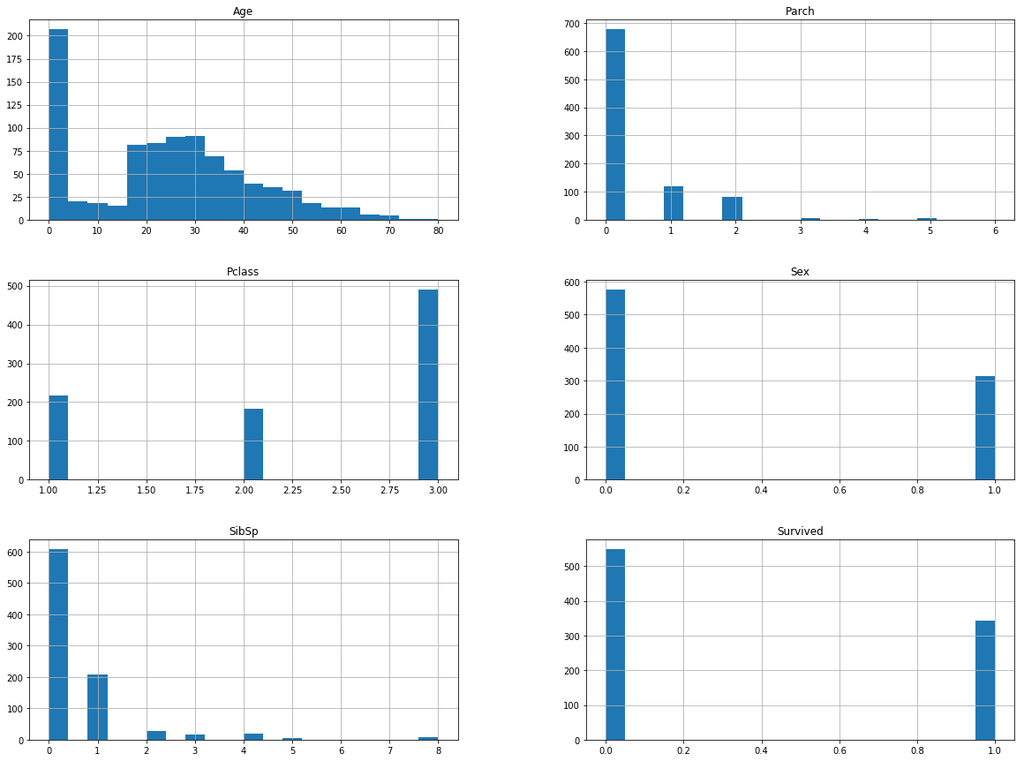

```python
quantdata.hist(bins = 20, figsize=(20,15));
```

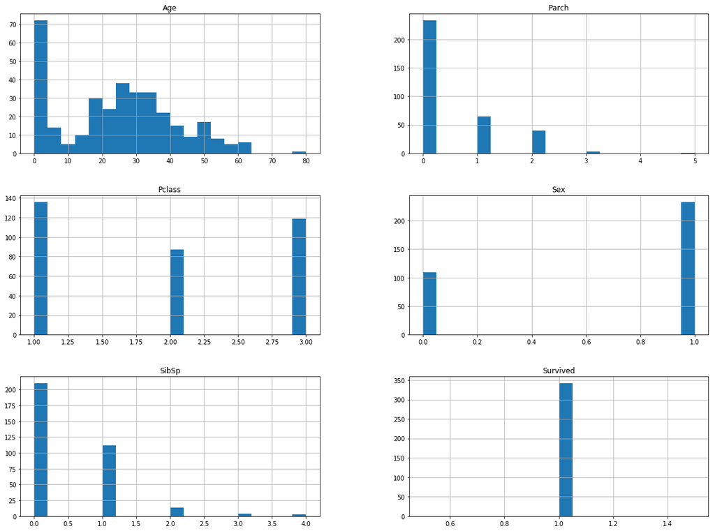

```python
quantdata[quantdata['Survived']==1].hist(bins = 20, figsize=(20,15));
```

## It seems that your chances of survival were higher if you were traveling in 1st class, let us check this ....

```
216
24.24% of the total passengers were traveling on 1st class
```

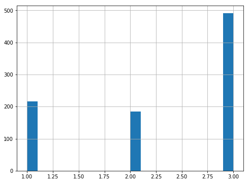

```python
quantdata['Pclass'].hist(bins = 20, figsize=(8,6));
# clearly the majority of people are traveling in lower class
print(len(quantdata['Pclass'][quantdata['Pclass']==1]))
print('{:.02f}% of the total passengers were traveling on 1st class'.format((216/891)*100))
```

```
136
216
62.96% of the passengers on 1st class survived
That is interesting !!
since it is almost double the Titanic Survival rate of 38.38%.
```

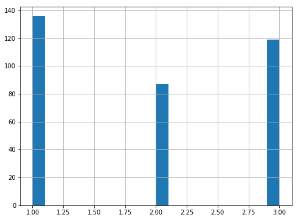

```python
quantdata['Pclass'][quantdata['Survived']==1].hist(bins = 20, figsize=(8,6));
# clearly the majority of people are traveling in lower class
firstsurv = len(quantdata['Pclass'][(quantdata['Pclass']==1)&(quantdata['Survived']==1)])
firstcust = len(quantdata['Pclass'][quantdata['Pclass']==1])
print(firstsurv)
print(firstcust)
print ('{:.02f}% of the passengers on 1st class survived'.format((firstsurv/firstcust)*100))
print("That is interesting !! \nsince it is almost double the Titanic Survival rate of {:.02f}%.".format((len(outcomes[outcomes !=0])/len(outcomes))*100))
```

> **Interesting!!!:** Disregarding of the sex or age or age 63% of the 1st class passengers survived, so clearly to travel on 1st class carried some advantages

## Let us go 1 step further an isolate the so far most important characteristics of the survivors, let us see how many females, under 11 and first class passengers survived

```python
print('Female Survivors: {}'.format(len(quantdata[(quantdata['Survived']==1) & (quantdata['Sex']==1)])))
print('Under 11 Survivors: {}'.format(len(quantdata[(quantdata['Survived']==1) & (quantdata['Age']<11)& (quantdata['Age']>0)])))
print('1st Class Survivors: {}'.format(len(quantdata[(quantdata['Survived']==1) & (quantdata['Pclass']==1)])))
print('Total Survivors: {}'.format(len(quantdata[(quantdata['Survived']==1)])))
print('Females < 11 on 1st Class Survivors: {}'.format(len(quantdata[(quantdata['Pclass']==1) & (quantdata['Sex']==1) & (quantdata['Age']<11)& (quantdata['Age']>0)])))
print('Males on 1st Class Survivors: {}'.format(len(quantdata[(quantdata['Pclass']==1) & (quantdata['Sex']==0)])))
print('Male on 1st Class Survivors: {}'.format(len(quantdata[(quantdata['Pclass']==1) & (quantdata['Sex']==0) & (quantdata['Survived']==1)])))
print('Male Survivors: {}'.format(len(quantdata[(quantdata['Survived']==1) & (quantdata['Sex']==0)])))
print('Male Passengers: {}'.format(len(quantdata[(quantdata['Sex']==0)])))
print("Male Survivors / Males on 1st Class {:.02f}%.".format(round(45/122,2)*100))
print("Male Survivors / Males on the boat {:.02f}%.".format(round(109/577,2)*100))
print('Males < 11 on 1st Class Survivors: {}'.format(len(quantdata[(quantdata['Pclass']==1) & (quantdata['Sex']==0) & (quantdata['Survived']==1)& (quantdata['Age']<11)& (quantdata['Age']>0)])))
print("Male Survivors <11 on 1st Class / Males Survivors on 1st Class {:.02f}%.".format(round(2/45,2)*100))
```

```
Female Survivors: 233
Under 11 Survivors: 38
1st Class Survivors: 136
Total Survivors: 342
Females < 11 on 1st Class Survivors: 1
Males on 1st Class Survivors: 122
Male on 1st Class Survivors: 45
Male Survivors: 109
Male Passengers: 577
Male Survivors / Males on 1st Class 37.00%.
Male Survivors / Males on the boat 19.00%.
Males < 11 on 1st Class Survivors: 2
Male Survivors <11 on 1st Class / Males Survivors on 1st Class 4.00%.
```

> **Conclusion:**
> 1. Men traveling on 1st class had twice the chances of survival of the average male traveling in the Titanic
> 2. Age was not a constrain for males on 1st class only 4% of the male survivors were under 11 years old

## Let us analyze the age distribution of the male survivors on 1st class

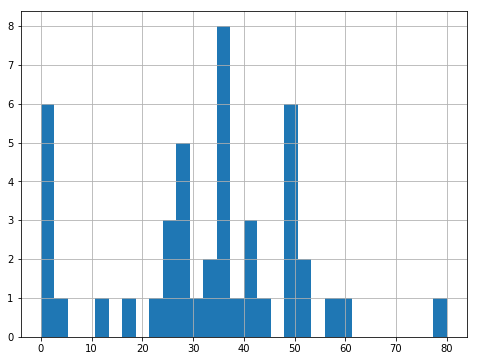

```python
quantdata['Age'][(quantdata['Pclass']==1) & (quantdata['Sex']==0) & (quantdata['Survived']==1)].hist(bins = 30, figsize=(8,6));
```

## Let us compare this versus the age distribution of males on 1st class

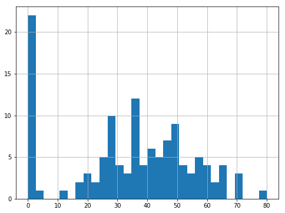

```python
quantdata['Age'][(quantdata['Pclass']==1) & (quantdata['Sex']==0) ].hist(bins = 30, figsize=(8,6));
```

> **Conclusion:** It seems that middle age males on 1st class ranging from 20 to 55 years were more successful at surviving than young boys or elder males

### Let us incorporate our findings into the analysis

```python
def predictions_3(data):
    """ Model with multiple features. Makes a prediction with an accuracy of at least 80%. """

    predictions4 = []
    for age, sex, clase in zip(data['Age'],data['Sex'],data['Pclass']):
        if sex == 'female':
            predictions4.append(1)
        elif (sex == 'male') & (age < 11)& (age > 0):
            predictions4.append(1)
        elif (sex == 'male') & (age < 55)& (age > 19) & (clase == 1):
            predictions4.append(1)
        else:
            predictions4.append(0)

    return pd.Series(predictions4)

# Make the predictions
predictions4 = predictions_3(data)
```

### Question 4

```python
print (accuracy_score(outcomes, predictions4))
```

```
Predictions have an accuracy of 81.24%.
```

**Answer**: *It seems a case of overfitting in the sense that by trying to add more explanatory variables our predicting algorithm is over estimating the number of survivors decreasing the prediction accuracy with respect to the previous implementation*

# Conclusion

After several iterations of exploring and conditioning on the data, you have built a useful algorithm for predicting the survival of each passenger aboard the RMS Titanic. The technique applied in this project is a manual implementation of a simple machine learning model, the *decision tree*. A decision tree splits a set of data into smaller and smaller groups (called *nodes*), by one feature at a time. Each time a subset of the data is split, our predictions become more accurate if each of the resulting subgroups are more homogeneous (contain similar labels) than before. The advantage of having a computer do things for us is that it will be more exhaustive and more precise than our manual exploration above. [This link](http://www.r2d3.us/visual-intro-to-machine-learning-part-1/) provides another introduction into machine learning using a decision tree.

A decision tree is just one of many models that come from *supervised learning*. In supervised learning, we attempt to use features of the data to predict or model things with objective outcome labels. That is to say, each of our data points has a known outcome value, such as a categorical, discrete label like `'Survived'`, or a numerical, continuous value like predicting the price of a house.

### Question 5

*Think of a real-world scenario where supervised learning could be applied. What would be the outcome variable that you are trying to predict? Name two features about the data used in this scenario that might be helpful for making the predictions.*

**Answer**: *An application or real-world scenario would be predicting sales in a convenience store. Two features which probably would have predicting power would be the sex of the individual and race, since different races have different consuming patters in terms of food types while the sex of course would also provide clear difference in consuming patters*

> **Note**: Once you have completed all of the code implementations and successfully answered each question above, you may finalize your work by exporting the iPython Notebook as an HTML document. You can do this by using the menu above and navigating to  
> **File -> Download as -> HTML (.html)**. Include the finished document along with this notebook as your submission.